# Title: Presidential Inagural Addresses Based on Party

## Author: Lara Mechling

## Course: DSC 360

## Professor: Werner

## Date Began: 2022-07-07

## Date Finalized:

### Milestone 3:

Get the data into a usable format and perform at least three different aspects of feature engineering.

#### Examples:

*Normalize the Corpus

*Bag of Words Modeling

*Bag of N-Grams Modeling

*Topic Modeling

*Clustering

In this project I hope to look at the differences between the Democratic, Republican, and 'Other' party inagural speeches. The other parties consist of a grouping of parties prior to the inception of the modern day republican and democratic parties.

I will use unsupervised learning throughout the course of the project rather than predefinded classification in order to determine if there are any innate characteristics to the data, rather than forcing them into predetermined trends.

```python
'''
Text Analytics with Python
Dipanjan Sarkar
Used throughout project
'''
```

```
'\nText Analytics with Python\nDipanjan Sarkar\nUsed throughout project\n'
```

```python
#imports
import nltk
from nltk.corpus import inaugural
import pandas as pd
from normalizer import Normalizer
import numpy as np
from sklearn.feature_extraction.text import TfidfVectorizer
import re
import matplotlib.pyplot as plt
from collections import Counter
from wordcloud import WordCloud

%matplotlib inline
```

```python
'''
nltk.org
1.5 Inaugural Address Corpus
'''

#view the fields contained in the corpus
inaugural.fileids()[:10]
```

```
['1789-Washington.txt',
 '1793-Washington.txt',
 '1797-Adams.txt',
 '1801-Jefferson.txt',
 '1805-Jefferson.txt',
 '1809-Madison.txt',
 '1813-Madison.txt',
 '1817-Monroe.txt',
 '1821-Monroe.txt',
 '1825-Adams.txt']
```

```python
'''
Stack Overflow
https://stackoverflow.com/questions/46109166/converting-categorizedplaintextcorpusreader-into-dataframe
'''

#convert inaugural into a pandas dataframe with each speech as a row
speeches= []
for fileid in inaugural.fileids():
    year, president= fileid.split('-')
    speeches.append((year, president, inaugural.raw(fileid)))

speech_df= pd.DataFrame(speeches, columns= ['year', 'president', 'speeches'])
speech_df.sample(5)
```

|  | year | president | speeches |
| --- | --- | --- | --- |
| 44 | 1965 | Johnson.txt | My fellow countrymen, on this occasion, the oa... |
| 2 | 1797 | Adams.txt | When it was first perceived, in early times, t... |
| 50 | 1989 | Bush.txt | Mr. Chief Justice, Mr. President, Vice Preside... |
| 36 | 1933 | Roosevelt.txt | I am certain that my fellow Americans expect t... |
| 4 | 1805 | Jefferson.txt | Proceeding, fellow citizens, to that qualifica... |

```python
'''
Stack Overflow
https://stackoverflow.com/questions/37001787/remove-ends-of-string-entries-in-pandas-dataframe-column
'''

#remove .txt from president column
speech_df['president']= speech_df['president'].str.rstrip('.txt')
speech_df.sample(5)
```

|  | year | president | speeches |
| --- | --- | --- | --- |
| 34 | 1925 | Coolidge | My countrymen,\n\nno one can contemplate curre... |
| 6 | 1813 | Madison | About to add the solemnity of an oath to the o... |
| 19 | 1865 | Lincoln | Fellow-Countrymen:\n\nAt this second appearing... |
| 47 | 1977 | Carter | For myself and for our Nation, I want to thank... |
| 4 | 1805 | Jefferson | Proceeding, fellow citizens, to that qualifica... |

### Normalizing Text

For the first step of the project I will normalize the text corpa. I will use the Normalizer.py function created at the beginning of this course in order to setup the text to be able to be processed by the following models and evaluation techniques.

```python
'''
Stack Overflow
https://stackoverflow.com/questions/40020326/how-to-remove-words-containing-only-numbers-in-python
'''

#will utilize both inagural addresses as a whole and broken into their individual addresses so will normalize in both fashions

#instantiate classes of Normalizer
normalize_whole= Normalizer(inaugural)

normalizer_df= Normalizer(speech_df['speeches'])

#remove numbers
def remove_numbers(corpus):
    norm_corpus= re.sub(r'\b[0-9]+\b\s*', '', corpus)
    return norm_corpus
```

```python
#normalize dataframe corpus
speech_df['speeches_norm']= normalizer_df.normalized_corpus(speech_df['speeches'])
```

```python
speech_df.sample(5)
```

|  | year | president | speeches | speeches_norm |
| --- | --- | --- | --- | --- |
| 9 | 1825 | Adams | In compliance with an usage coeval with the ex... | compliance usage coeval existence federal cons... |
| 26 | 1893 | Cleveland | My Fellow citizens, in obedience of the mandat... | fellow citizen obedience mandate countryman de... |
| 50 | 1989 | Bush | Mr. Chief Justice, Mr. President, Vice Preside... | mr chief justice mr president vice president q... |
| 22 | 1877 | Hayes | Fellow citizens, we have assembled to repeat t... | fellow citizen assemble repeat public ceremoni... |
| 48 | 1981 | Reagan | Senator Hatfield, Mr. Chief Justice, Mr. Presi... | senator hatfield mr chief justice mr president... |

In order to evaluate the speeches I assigned the respective parties to the presidents for each speech and added the information to the dataframe.

```python
'''
The Guardian
https://www.theguardian.com/news/datablog/2012/oct/15/us-presidents-listed
'''

#add presidential parties to dataframe
parties= pd.Series(['other', 'other', 'other', 'other', 'other', 'other', 'other', 'other', 'other', 'other', 'democrat', 'democrat', 'democrat',
                    'other', 'democrat', 'other', 'democrat', 'democrat', 'republican', 'rebublican', 'republican', 'republican', 'republican',
                    'republican', 'democrat', 'republican', 'democrat', 'republican', 'republican', 'republican', 'republican', 'democrat',
                    'democrat', 'republican', 'republican', 'republican', 'democrat', 'democrat', 'democrat', 'democrat', 'democrat', 'republican',
                    'republican', 'democrat', 'democrat', 'republican', 'republican', 'democrat', 'republican', 'republican', 'republican',
                    'democrat', 'democrat', 'republican', 'republican', 'democrat', 'democrat', 'republican', 'democrat'])
```

```python
speech_df['party']= parties
speech_df.sample(5)
```

|  | year | president | speeches | speeches_norm | party |
| --- | --- | --- | --- | --- | --- |
| 47 | 1977 | Carter | For myself and for our Nation, I want to thank... | nation want thank predecessor heal land outwar... | democrat |
| 49 | 1985 | Reagan | Senator Mathias, Chief Justice Burger, Vice Pr... | senator mathias chief justice burger vice pres... | republican |
| 16 | 1853 | Pierce | My Countrymen, It a relief to feel that no hea... | countryman relief feel no heart know personal ... | democrat |
| 0 | 1789 | Washington | Fellow-Citizens of the Senate and of the House... | fellow citizen senate house representatives am... | other |
| 35 | 1929 | Hoover | My Countrymen: This occasion is not alone the ... | countryman occasion not alone administration s... | republican |

Here I will split the dataset into individual parties to prevent having to sort throughout the course of the project and create an array of the data to be used for certain techniques.

```python
#split into respective political parties
other= speech_df.query('party == "other"')
republican= speech_df.query('party == "republican"')
democrat= speech_df.query('party == "democrat"')
```

```python
#convert speeches_norm to array for feature engineering
other_norm_array= other['speeches_norm'].to_numpy()
republican_norm_array= republican['speeches_norm'].to_numpy()
democrat_norm_array= democrat['speeches_norm'].to_numpy()
speech_norm_array= speech_df['speeches_norm'].to_numpy()
```

#### Cluster and Document Similarity Across Parties

The first distinguishing feature I would like to look at is the clustering of the speeches. Through the clustering method I hope to see if there are characteristics that place each different party's speeches into respective categories, and if those categories align with the different parties. I perfect result would be 3 clusters with the democratic, republican, and other speeches each falling into it's own cluster.

```python
#tf-idf vectorizer
tv= TfidfVectorizer(min_df= 5, max_df= 0.95, norm= 'l2', use_idf= True, smooth_idf= True)
tv_matrix= tv.fit_transform(speech_norm_array)
tv_matrix= tv_matrix.toarray()
tv_matrix.shape
```

```
(59, 1964)
```

```python
vocab= tv.get_feature_names_out()
pd.DataFrame(np.round(tv_matrix, 2), columns= vocab)
```

|  | abandon | abide | ability | able | abolish | aboriginal | abroad | absence | absolute | abundance | ... | write | wrong | year | yes | yet | yield | young | zeal | zealous | zealously |
| --- | --- | --- | --- | --- | --- | --- | --- | --- | --- | --- | --- | --- | --- | --- | --- | --- | --- | --- | --- | --- | --- |
| 0 | 0.00 | 0.00 | 0.00 | 0.00 | 0.00 | 0.00 | 0.00 | 0.00 | 0.00 | 0.00 | ... | 0.00 | 0.00 | 0.02 | 0.00 | 0.00 | 0.00 | 0.00 | 0.00 | 0.00 | 0.00 |
| 1 | 0.00 | 0.00 | 0.00 | 0.00 | 0.00 | 0.00 | 0.00 | 0.00 | 0.00 | 0.00 | ... | 0.00 | 0.00 | 0.00 | 0.00 | 0.00 | 0.00 | 0.00 | 0.00 | 0.00 | 0.00 |
| 2 | 0.03 | 0.00 | 0.00 | 0.00 | 0.00 | 0.04 | 0.02 | 0.00 | 0.00 | 0.00 | ... | 0.00 | 0.00 | 0.07 | 0.00 | 0.00 | 0.00 | 0.00 | 0.03 | 0.00 | 0.00 |
| 3 | 0.04 | 0.00 | 0.00 | 0.00 | 0.00 | 0.00 | 0.03 | 0.00 | 0.04 | 0.00 | ... | 0.03 | 0.05 | 0.00 | 0.00 | 0.04 | 0.00 | 0.00 | 0.04 | 0.00 | 0.00 |
| 4 | 0.00 | 0.00 | 0.00 | 0.03 | 0.00 | 0.04 | 0.00 | 0.00 | 0.00 | 0.00 | ... | 0.02 | 0.00 | 0.05 | 0.00 | 0.03 | 0.00 | 0.00 | 0.10 | 0.00 | 0.00 |
| 5 | 0.00 | 0.00 | 0.00 | 0.00 | 0.00 | 0.06 | 0.00 | 0.00 | 0.00 | 0.00 | ... | 0.00 | 0.00 | 0.00 | 0.00 | 0.00 | 0.00 | 0.00 | 0.00 | 0.00 | 0.06 |
| 6 | 0.00 | 0.00 | 0.00 | 0.00 | 0.00 | 0.00 | 0.00 | 0.00 | 0.00 | 0.00 | ... | 0.00 | 0.03 | 0.00 | 0.00 | 0.00 | 0.00 | 0.00 | 0.00 | 0.00 | 0.00 |
| 7 | 0.00 | 0.00 | 0.00 | 0.04 | 0.00 | 0.00 | 0.02 | 0.00 | 0.00 | 0.00 | ... | 0.00 | 0.00 | 0.02 | 0.00 | 0.00 | 0.00 | 0.00 | 0.02 | 0.03 | 0.00 |
| 8 | 0.03 | 0.00 | 0.01 | 0.02 | 0.00 | 0.00 | 0.00 | 0.00 | 0.00 | 0.00 | ... | 0.00 | 0.00 | 0.08 | 0.00 | 0.01 | 0.02 | 0.00 | 0.00 | 0.02 | 0.02 |
| 9 | 0.00 | 0.00 | 0.02 | 0.00 | 0.00 | 0.03 | 0.02 | 0.00 | 0.00 | 0.00 | ... | 0.00 | 0.02 | 0.09 | 0.00 | 0.00 | 0.04 | 0.00 | 0.03 | 0.00 | 0.00 |
| 10 | 0.00 | 0.00 | 0.04 | 0.04 | 0.00 | 0.00 | 0.00 | 0.00 | 0.00 | 0.00 | ... | 0.00 | 0.00 | 0.00 | 0.00 | 0.00 | 0.00 | 0.00 | 0.05 | 0.06 | 0.00 |
| 11 | 0.04 | 0.00 | 0.07 | 0.00 | 0.00 | 0.00 | 0.00 | 0.00 | 0.00 | 0.00 | ... | 0.00 | 0.03 | 0.02 | 0.00 | 0.00 | 0.04 | 0.00 | 0.00 | 0.00 | 0.00 |
| 12 | 0.00 | 0.02 | 0.03 | 0.00 | 0.02 | 0.00 | 0.05 | 0.00 | 0.00 | 0.00 | ... | 0.00 | 0.00 | 0.03 | 0.00 | 0.09 | 0.00 | 0.00 | 0.00 | 0.00 | 0.02 |
| 13 | 0.00 | 0.00 | 0.01 | 0.00 | 0.00 | 0.01 | 0.00 | 0.01 | 0.00 | 0.00 | ... | 0.02 | 0.00 | 0.03 | 0.00 | 0.03 | 0.01 | 0.00 | 0.00 | 0.00 | 0.01 |
| 14 | 0.00 | 0.00 | 0.03 | 0.00 | 0.02 | 0.00 | 0.01 | 0.02 | 0.00 | 0.00 | ... | 0.01 | 0.01 | 0.01 | 0.00 | 0.02 | 0.00 | 0.01 | 0.00 | 0.00 | 0.00 |
| 15 | 0.00 | 0.00 | 0.04 | 0.04 | 0.00 | 0.00 | 0.00 | 0.06 | 0.00 | 0.00 | ... | 0.00 | 0.00 | 0.00 | 0.00 | 0.00 | 0.00 | 0.00 | 0.00 | 0.00 | 0.06 |
| 16 | 0.00 | 0.00 | 0.00 | 0.00 | 0.00 | 0.00 | 0.06 | 0.00 | 0.03 | 0.00 | ... | 0.00 | 0.02 | 0.01 | 0.00 | 0.01 | 0.00 | 0.00 | 0.00 | 0.00 | 0.00 |
| 17 | 0.00 | 0.00 | 0.02 | 0.00 | 0.00 | 0.00 | 0.00 | 0.00 | 0.00 | 0.00 | ... | 0.00 | 0.00 | 0.02 | 0.00 | 0.05 | 0.00 | 0.00 | 0.00 | 0.00 | 0.00 |
| 18 | 0.00 | 0.04 | 0.01 | 0.00 | 0.00 | 0.00 | 0.00 | 0.00 | 0.00 | 0.00 | ... | 0.06 | 0.01 | 0.03 | 0.00 | 0.03 | 0.00 | 0.00 | 0.00 | 0.00 | 0.00 |
| 19 | 0.00 | 0.00 | 0.00 | 0.00 | 0.00 | 0.00 | 0.00 | 0.00 | 0.00 | 0.00 | ... | 0.00 | 0.00 | 0.11 | 0.00 | 0.04 | 0.00 | 0.00 | 0.00 | 0.00 | 0.00 |
| 20 | 0.00 | 0.04 | 0.10 | 0.00 | 0.00 | 0.00 | 0.00 | 0.00 | 0.00 | 0.00 | ... | 0.00 | 0.00 | 0.08 | 0.00 | 0.00 | 0.00 | 0.04 | 0.00 | 0.00 | 0.00 |
| 21 | 0.00 | 0.00 | 0.00 | 0.00 | 0.00 | 0.00 | 0.00 | 0.00 | 0.00 | 0.00 | ... | 0.00 | 0.06 | 0.06 | 0.00 | 0.03 | 0.00 | 0.00 | 0.00 | 0.00 | 0.00 |
| 22 | 0.00 | 0.00 | 0.00 | 0.04 | 0.00 | 0.00 | 0.02 | 0.00 | 0.00 | 0.00 | ... | 0.00 | 0.02 | 0.02 | 0.00 | 0.01 | 0.02 | 0.00 | 0.00 | 0.03 | 0.00 |
| 23 | 0.00 | 0.00 | 0.00 | 0.00 | 0.00 | 0.00 | 0.00 | 0.00 | 0.03 | 0.00 | ... | 0.02 | 0.03 | 0.04 | 0.00 | 0.03 | 0.02 | 0.00 | 0.00 | 0.00 | 0.00 |
| 24 | 0.03 | 0.00 | 0.00 | 0.00 | 0.00 | 0.00 | 0.00 | 0.00 | 0.00 | 0.00 | ... | 0.00 | 0.00 | 0.02 | 0.00 | 0.00 | 0.00 | 0.00 | 0.04 | 0.00 | 0.00 |
| 25 | 0.00 | 0.03 | 0.00 | 0.05 | 0.00 | 0.00 | 0.00 | 0.00 | 0.00 | 0.00 | ... | 0.00 | 0.00 | 0.02 | 0.00 | 0.03 | 0.02 | 0.03 | 0.00 | 0.00 | 0.00 |
| 26 | 0.00 | 0.00 | 0.03 | 0.00 | 0.00 | 0.00 | 0.00 | 0.00 | 0.00 | 0.00 | ... | 0.00 | 0.02 | 0.00 | 0.00 | 0.00 | 0.00 | 0.00 | 0.00 | 0.00 | 0.00 |
| 27 | 0.00 | 0.02 | 0.07 | 0.00 | 0.00 | 0.00 | 0.01 | 0.02 | 0.00 | 0.00 | ... | 0.00 | 0.00 | 0.09 | 0.00 | 0.01 | 0.00 | 0.00 | 0.06 | 0.02 | 0.00 |
| 28 | 0.03 | 0.03 | 0.02 | 0.00 | 0.00 | 0.00 | 0.02 | 0.00 | 0.00 | 0.00 | ... | 0.00 | 0.00 | 0.05 | 0.00 | 0.02 | 0.00 | 0.00 | 0.00 | 0.00 | 0.00 |
| 29 | 0.00 | 0.00 | 0.00 | 0.10 | 0.00 | 0.00 | 0.00 | 0.00 | 0.00 | 0.00 | ... | 0.00 | 0.04 | 0.00 | 0.00 | 0.12 | 0.00 | 0.00 | 0.00 | 0.00 | 0.00 |
| 30 | 0.00 | 0.00 | 0.00 | 0.04 | 0.02 | 0.00 | 0.03 | 0.00 | 0.01 | 0.00 | ... | 0.00 | 0.00 | 0.03 | 0.00 | 0.01 | 0.00 | 0.00 | 0.00 | 0.00 | 0.00 |
| 31 | 0.00 | 0.00 | 0.00 | 0.03 | 0.00 | 0.00 | 0.00 | 0.00 | 0.00 | 0.04 | ... | 0.03 | 0.05 | 0.05 | 0.00 | 0.06 | 0.00 | 0.00 | 0.00 | 0.00 | 0.00 |
| 32 | 0.00 | 0.00 | 0.00 | 0.00 | 0.00 | 0.00 | 0.00 | 0.00 | 0.00 | 0.00 | ... | 0.00 | 0.08 | 0.05 | 0.00 | 0.04 | 0.00 | 0.00 | 0.00 | 0.00 | 0.00 |
| 33 | 0.00 | 0.00 | 0.02 | 0.00 | 0.00 | 0.00 | 0.00 | 0.00 | 0.00 | 0.00 | ... | 0.03 | 0.01 | 0.00 | 0.00 | 0.02 | 0.00 | 0.00 | 0.00 | 0.00 | 0.00 |
| 34 | 0.00 | 0.00 | 0.00 | 0.02 | 0.00 | 0.00 | 0.05 | 0.00 | 0.02 | 0.00 | ... | 0.00 | 0.01 | 0.03 | 0.00 | 0.00 | 0.00 | 0.00 | 0.00 | 0.00 | 0.00 |
| 35 | 0.02 | 0.04 | 0.06 | 0.00 | 0.00 | 0.00 | 0.04 | 0.00 | 0.02 | 0.00 | ... | 0.00 | 0.00 | 0.02 | 0.00 | 0.03 | 0.00 | 0.00 | 0.00 | 0.00 | 0.02 |
| 36 | 0.00 | 0.00 | 0.03 | 0.00 | 0.00 | 0.00 | 0.00 | 0.00 | 0.00 | 0.00 | ... | 0.00 | 0.00 | 0.01 | 0.00 | 0.02 | 0.00 | 0.03 | 0.00 | 0.00 | 0.00 |
| 37 | 0.03 | 0.03 | 0.02 | 0.00 | 0.00 | 0.00 | 0.00 | 0.04 | 0.00 | 0.04 | ... | 0.03 | 0.00 | 0.07 | 0.00 | 0.00 | 0.03 | 0.00 | 0.00 | 0.00 | 0.00 |
| 38 | 0.00 | 0.00 | 0.00 | 0.00 | 0.00 | 0.00 | 0.00 | 0.00 | 0.00 | 0.00 | ... | 0.07 | 0.00 | 0.13 | 0.00 | 0.02 | 0.00 | 0.00 | 0.00 | 0.00 | 0.00 |
| 39 | 0.00 | 0.00 | 0.00 | 0.00 | 0.00 | 0.00 | 0.00 | 0.00 | 0.00 | 0.00 | ... | 0.00 | 0.00 | 0.07 | 0.00 | 0.04 | 0.00 | 0.00 | 0.00 | 0.00 | 0.00 |
| 40 | 0.02 | 0.00 | 0.02 | 0.00 | 0.00 | 0.00 | 0.00 | 0.00 | 0.00 | 0.06 | ... | 0.00 | 0.02 | 0.02 | 0.00 | 0.00 | 0.00 | 0.00 | 0.00 | 0.00 | 0.00 |
| 41 | 0.00 | 0.03 | 0.00 | 0.00 | 0.00 | 0.00 | 0.00 | 0.00 | 0.00 | 0.00 | ... | 0.00 | 0.02 | 0.00 | 0.00 | 0.02 | 0.00 | 0.00 | 0.00 | 0.00 | 0.00 |
| 42 | 0.00 | 0.00 | 0.00 | 0.00 | 0.00 | 0.00 | 0.00 | 0.00 | 0.00 | 0.00 | ... | 0.00 | 0.00 | 0.02 | 0.00 | 0.06 | 0.03 | 0.00 | 0.00 | 0.00 | 0.00 |
| 43 | 0.00 | 0.00 | 0.00 | 0.00 | 0.05 | 0.00 | 0.00 | 0.00 | 0.08 | 0.00 | ... | 0.00 | 0.00 | 0.03 | 0.00 | 0.04 | 0.00 | 0.03 | 0.00 | 0.00 | 0.00 |
| 44 | 0.04 | 0.00 | 0.00 | 0.00 | 0.00 | 0.00 | 0.00 | 0.00 | 0.00 | 0.05 | ... | 0.06 | 0.00 | 0.05 | 0.00 | 0.00 | 0.00 | 0.03 | 0.00 | 0.00 | 0.00 |
| 45 | 0.00 | 0.00 | 0.00 | 0.00 | 0.00 | 0.00 | 0.02 | 0.00 | 0.00 | 0.00 | ... | 0.02 | 0.00 | 0.08 | 0.00 | 0.00 | 0.00 | 0.00 | 0.00 | 0.00 | 0.00 |
| 46 | 0.00 | 0.00 | 0.00 | 0.02 | 0.00 | 0.00 | 0.17 | 0.00 | 0.00 | 0.03 | ... | 0.00 | 0.02 | 0.11 | 0.00 | 0.00 | 0.00 | 0.02 | 0.00 | 0.00 | 0.00 |
| 47 | 0.00 | 0.05 | 0.00 | 0.04 | 0.00 | 0.00 | 0.04 | 0.00 | 0.05 | 0.00 | ... | 0.00 | 0.00 | 0.04 | 0.00 | 0.00 | 0.00 | 0.00 | 0.00 | 0.00 | 0.00 |
| 48 | 0.00 | 0.00 | 0.00 | 0.00 | 0.00 | 0.00 | 0.00 | 0.00 | 0.00 | 0.00 | ... | 0.02 | 0.00 | 0.04 | 0.03 | 0.03 | 0.00 | 0.05 | 0.00 | 0.00 | 0.00 |
| 49 | 0.00 | 0.00 | 0.00 | 0.00 | 0.00 | 0.00 | 0.00 | 0.00 | 0.00 | 0.00 | ... | 0.02 | 0.00 | 0.09 | 0.05 | 0.06 | 0.02 | 0.04 | 0.00 | 0.00 | 0.00 |
| 50 | 0.00 | 0.00 | 0.00 | 0.00 | 0.00 | 0.00 | 0.00 | 0.00 | 0.00 | 0.00 | ... | 0.05 | 0.00 | 0.02 | 0.06 | 0.00 | 0.03 | 0.09 | 0.00 | 0.00 | 0.00 |
| 51 | 0.00 | 0.03 | 0.00 | 0.03 | 0.00 | 0.00 | 0.02 | 0.00 | 0.00 | 0.00 | ... | 0.00 | 0.02 | 0.00 | 0.03 | 0.00 | 0.00 | 0.05 | 0.00 | 0.00 | 0.00 |
| 52 | 0.00 | 0.00 | 0.00 | 0.00 | 0.03 | 0.00 | 0.00 | 0.00 | 0.00 | 0.00 | ... | 0.00 | 0.02 | 0.03 | 0.11 | 0.04 | 0.00 | 0.02 | 0.00 | 0.00 | 0.00 |
| 53 | 0.00 | 0.00 | 0.00 | 0.00 | 0.00 | 0.00 | 0.00 | 0.00 | 0.00 | 0.00 | ... | 0.03 | 0.02 | 0.03 | 0.00 | 0.07 | 0.03 | 0.03 | 0.00 | 0.00 | 0.00 |
| 54 | 0.05 | 0.00 | 0.00 | 0.00 | 0.00 | 0.00 | 0.00 | 0.00 | 0.00 | 0.00 | ... | 0.00 | 0.02 | 0.04 | 0.00 | 0.05 | 0.00 | 0.05 | 0.00 | 0.00 | 0.00 |
| 55 | 0.03 | 0.00 | 0.02 | 0.00 | 0.00 | 0.00 | 0.00 | 0.00 | 0.00 | 0.00 | ... | 0.00 | 0.02 | 0.04 | 0.03 | 0.03 | 0.00 | 0.02 | 0.00 | 0.00 | 0.00 |
| 56 | 0.00 | 0.00 | 0.00 | 0.00 | 0.00 | 0.00 | 0.02 | 0.00 | 0.00 | 0.00 | ... | 0.00 | 0.00 | 0.07 | 0.00 | 0.00 | 0.00 | 0.03 | 0.00 | 0.00 | 0.00 |
| 57 | 0.00 | 0.00 | 0.00 | 0.00 | 0.00 | 0.00 | 0.00 | 0.00 | 0.00 | 0.00 | ... | 0.00 | 0.00 | 0.03 | 0.04 | 0.00 | 0.00 | 0.03 | 0.00 | 0.00 | 0.00 |
| 58 | 0.00 | 0.00 | 0.00 | 0.00 | 0.00 | 0.00 | 0.00 | 0.00 | 0.00 | 0.00 | ... | 0.06 | 0.02 | 0.05 | 0.03 | 0.04 | 0.00 | 0.00 | 0.00 | 0.00 | 0.00 |

59 rows × 1964 columns

```python
#document similarity
from sklearn.metrics.pairwise import cosine_similarity
```

```python
similarity_matrix= cosine_similarity(tv_matrix)
similarity_df= pd.DataFrame(similarity_matrix)
similarity_df
```

|  | 0 | 1 | 2 | 3 | 4 | 5 | 6 | 7 | 8 | 9 | ... | 49 | 50 | 51 | 52 | 53 | 54 | 55 | 56 | 57 | 58 |
| --- | --- | --- | --- | --- | --- | --- | --- | --- | --- | --- | --- | --- | --- | --- | --- | --- | --- | --- | --- | --- | --- |
| 0 | 1.000000 | 0.173369 | 0.372384 | 0.332611 | 0.336521 | 0.312530 | 0.248677 | 0.398122 | 0.368933 | 0.346095 | ... | 0.222494 | 0.191198 | 0.149877 | 0.186139 | 0.202107 | 0.221672 | 0.212945 | 0.203556 | 0.156889 | 0.181261 |
| 1 | 0.173369 | 1.000000 | 0.166481 | 0.164906 | 0.157989 | 0.094477 | 0.121310 | 0.145263 | 0.150065 | 0.115503 | ... | 0.078910 | 0.068084 | 0.099074 | 0.070631 | 0.098479 | 0.131043 | 0.079218 | 0.118151 | 0.115167 | 0.103630 |
| 2 | 0.372384 | 0.166481 | 1.000000 | 0.394517 | 0.376645 | 0.352770 | 0.258703 | 0.458417 | 0.425178 | 0.459854 | ... | 0.247471 | 0.218405 | 0.197265 | 0.229413 | 0.224519 | 0.268353 | 0.237114 | 0.234843 | 0.203517 | 0.197069 |
| 3 | 0.332611 | 0.164906 | 0.394517 | 1.000000 | 0.413938 | 0.339587 | 0.242753 | 0.401191 | 0.348898 | 0.399998 | ... | 0.310529 | 0.279818 | 0.195802 | 0.259118 | 0.245316 | 0.275215 | 0.296386 | 0.270589 | 0.189899 | 0.251934 |
| 4 | 0.336521 | 0.157989 | 0.376645 | 0.413938 | 1.000000 | 0.335496 | 0.247411 | 0.429564 | 0.415002 | 0.385328 | ... | 0.228417 | 0.232753 | 0.167379 | 0.182838 | 0.226504 | 0.234124 | 0.238675 | 0.242372 | 0.140226 | 0.195003 |
| 5 | 0.312530 | 0.094477 | 0.352770 | 0.339587 | 0.335496 | 1.000000 | 0.272086 | 0.398561 | 0.361862 | 0.371831 | ... | 0.197006 | 0.160721 | 0.136193 | 0.149210 | 0.169855 | 0.203034 | 0.182750 | 0.182439 | 0.134689 | 0.174926 |
| 6 | 0.248677 | 0.121310 | 0.258703 | 0.242753 | 0.247411 | 0.272086 | 1.000000 | 0.350010 | 0.384268 | 0.245730 | ... | 0.174061 | 0.149784 | 0.135927 | 0.152029 | 0.195254 | 0.202290 | 0.199058 | 0.215204 | 0.141489 | 0.171305 |
| 7 | 0.398122 | 0.145263 | 0.458417 | 0.401191 | 0.429564 | 0.398561 | 0.350010 | 1.000000 | 0.638044 | 0.477986 | ... | 0.254786 | 0.231283 | 0.160280 | 0.207045 | 0.215970 | 0.231852 | 0.243071 | 0.235852 | 0.180710 | 0.192307 |
| 8 | 0.368933 | 0.150065 | 0.425178 | 0.348898 | 0.415002 | 0.361862 | 0.384268 | 0.638044 | 1.000000 | 0.434979 | ... | 0.254142 | 0.234432 | 0.178224 | 0.213832 | 0.220533 | 0.229057 | 0.250404 | 0.265381 | 0.182779 | 0.208834 |
| 9 | 0.346095 | 0.115503 | 0.459854 | 0.399998 | 0.385328 | 0.371831 | 0.245730 | 0.477986 | 0.434979 | 1.000000 | ... | 0.284601 | 0.207828 | 0.150577 | 0.220259 | 0.222553 | 0.235783 | 0.221371 | 0.244616 | 0.161112 | 0.182681 |
| 10 | 0.335422 | 0.166941 | 0.373761 | 0.321939 | 0.366958 | 0.359865 | 0.203610 | 0.411017 | 0.380233 | 0.380776 | ... | 0.189607 | 0.156676 | 0.123465 | 0.130106 | 0.178205 | 0.189400 | 0.171818 | 0.178269 | 0.121612 | 0.121949 |
| 11 | 0.322106 | 0.147266 | 0.373934 | 0.365571 | 0.308272 | 0.267020 | 0.208316 | 0.429514 | 0.377163 | 0.448781 | ... | 0.263841 | 0.183564 | 0.159543 | 0.182455 | 0.190382 | 0.204361 | 0.186141 | 0.200786 | 0.140039 | 0.171494 |
| 12 | 0.382242 | 0.165570 | 0.424133 | 0.406518 | 0.409149 | 0.373764 | 0.301945 | 0.485396 | 0.458777 | 0.440472 | ... | 0.280659 | 0.224864 | 0.180213 | 0.243141 | 0.258401 | 0.268126 | 0.292409 | 0.266134 | 0.208177 | 0.218247 |
| 13 | 0.401799 | 0.189071 | 0.494245 | 0.439207 | 0.432541 | 0.340495 | 0.294469 | 0.495216 | 0.505330 | 0.480697 | ... | 0.295641 | 0.284229 | 0.174201 | 0.237393 | 0.259088 | 0.285830 | 0.259249 | 0.283079 | 0.216269 | 0.238333 |
| 14 | 0.367751 | 0.163094 | 0.435877 | 0.424339 | 0.451988 | 0.340844 | 0.288220 | 0.569668 | 0.523196 | 0.556996 | ... | 0.320989 | 0.222166 | 0.172038 | 0.245385 | 0.208517 | 0.259898 | 0.232800 | 0.259492 | 0.210326 | 0.200507 |
| 15 | 0.310208 | 0.245007 | 0.358413 | 0.314949 | 0.301042 | 0.262249 | 0.224505 | 0.374027 | 0.349976 | 0.384650 | ... | 0.177458 | 0.165772 | 0.130962 | 0.143772 | 0.186964 | 0.173505 | 0.185172 | 0.171275 | 0.161486 | 0.165929 |
| 16 | 0.348123 | 0.175220 | 0.374343 | 0.390968 | 0.364295 | 0.357009 | 0.267405 | 0.418530 | 0.405156 | 0.441270 | ... | 0.292151 | 0.267682 | 0.204873 | 0.245104 | 0.230300 | 0.264646 | 0.288488 | 0.282109 | 0.206808 | 0.236783 |
| 17 | 0.353492 | 0.193374 | 0.427438 | 0.373036 | 0.382007 | 0.288006 | 0.268207 | 0.516820 | 0.473470 | 0.413224 | ... | 0.256712 | 0.211241 | 0.156620 | 0.213141 | 0.207245 | 0.241725 | 0.238662 | 0.229837 | 0.179575 | 0.197888 |
| 18 | 0.314123 | 0.221152 | 0.359090 | 0.361889 | 0.323558 | 0.263271 | 0.217862 | 0.395960 | 0.406218 | 0.407803 | ... | 0.258336 | 0.225406 | 0.161615 | 0.203708 | 0.187645 | 0.216973 | 0.205933 | 0.234592 | 0.162278 | 0.213658 |
| 19 | 0.175030 | 0.084106 | 0.168901 | 0.195791 | 0.204272 | 0.142758 | 0.244265 | 0.244339 | 0.281108 | 0.240170 | ... | 0.233294 | 0.184734 | 0.159826 | 0.193879 | 0.144835 | 0.159483 | 0.234651 | 0.202504 | 0.130601 | 0.211008 |
| 20 | 0.248048 | 0.137910 | 0.269990 | 0.251144 | 0.289949 | 0.225582 | 0.181409 | 0.287817 | 0.304373 | 0.281182 | ... | 0.192205 | 0.142689 | 0.107005 | 0.155681 | 0.159796 | 0.188922 | 0.212486 | 0.188499 | 0.171698 | 0.158970 |
| 21 | 0.258838 | 0.120268 | 0.295929 | 0.300632 | 0.297529 | 0.251136 | 0.229436 | 0.341209 | 0.368006 | 0.306125 | ... | 0.269903 | 0.228809 | 0.154814 | 0.216032 | 0.214696 | 0.211358 | 0.232398 | 0.220617 | 0.179496 | 0.196119 |
| 22 | 0.350397 | 0.152301 | 0.402550 | 0.345864 | 0.342893 | 0.310093 | 0.246334 | 0.423803 | 0.416938 | 0.434704 | ... | 0.264323 | 0.227562 | 0.170469 | 0.211761 | 0.235385 | 0.238722 | 0.237280 | 0.244794 | 0.172433 | 0.186996 |
| 23 | 0.287856 | 0.188457 | 0.392573 | 0.370157 | 0.343253 | 0.297234 | 0.232727 | 0.424658 | 0.405973 | 0.434655 | ... | 0.319390 | 0.260394 | 0.219059 | 0.299239 | 0.249915 | 0.303668 | 0.276975 | 0.288772 | 0.202948 | 0.228529 |
| 24 | 0.322212 | 0.220309 | 0.373204 | 0.351736 | 0.363470 | 0.256084 | 0.206786 | 0.388140 | 0.325784 | 0.392895 | ... | 0.242993 | 0.184579 | 0.171333 | 0.227145 | 0.230791 | 0.232373 | 0.213230 | 0.228424 | 0.193929 | 0.180544 |
| 25 | 0.304594 | 0.188008 | 0.391518 | 0.327377 | 0.397343 | 0.336233 | 0.251348 | 0.429095 | 0.424852 | 0.372816 | ... | 0.256406 | 0.253601 | 0.191613 | 0.236917 | 0.253921 | 0.259375 | 0.262284 | 0.236448 | 0.191346 | 0.196950 |
| 26 | 0.309866 | 0.135244 | 0.309411 | 0.330241 | 0.319123 | 0.255113 | 0.218755 | 0.358836 | 0.321312 | 0.323150 | ... | 0.251667 | 0.177295 | 0.167008 | 0.218854 | 0.261297 | 0.242510 | 0.236128 | 0.246307 | 0.177275 | 0.180165 |
| 27 | 0.313912 | 0.167239 | 0.397258 | 0.320754 | 0.340851 | 0.317348 | 0.262848 | 0.440776 | 0.461087 | 0.389386 | ... | 0.281457 | 0.253442 | 0.214349 | 0.234061 | 0.226861 | 0.246613 | 0.258923 | 0.278554 | 0.208659 | 0.207100 |
| 28 | 0.286603 | 0.139367 | 0.345239 | 0.315326 | 0.294099 | 0.272062 | 0.272020 | 0.401949 | 0.424068 | 0.367120 | ... | 0.296203 | 0.267093 | 0.205758 | 0.247260 | 0.213468 | 0.279450 | 0.259458 | 0.278195 | 0.183396 | 0.212243 |
| 29 | 0.165793 | 0.048576 | 0.222725 | 0.231253 | 0.220686 | 0.164107 | 0.135830 | 0.224039 | 0.220211 | 0.203023 | ... | 0.267473 | 0.295106 | 0.228737 | 0.270699 | 0.244049 | 0.234323 | 0.290268 | 0.260325 | 0.169601 | 0.249211 |
| 30 | 0.299000 | 0.141644 | 0.330147 | 0.290008 | 0.322214 | 0.256491 | 0.219347 | 0.394391 | 0.428756 | 0.339546 | ... | 0.290186 | 0.249402 | 0.212218 | 0.236974 | 0.214706 | 0.228532 | 0.246332 | 0.255581 | 0.195993 | 0.203537 |
| 31 | 0.227517 | 0.087095 | 0.252109 | 0.273213 | 0.223014 | 0.180785 | 0.164513 | 0.237750 | 0.233027 | 0.246162 | ... | 0.310210 | 0.344719 | 0.236158 | 0.298851 | 0.230538 | 0.278640 | 0.355773 | 0.268395 | 0.238253 | 0.259000 |
| 32 | 0.199675 | 0.095766 | 0.254174 | 0.278055 | 0.258376 | 0.245724 | 0.181889 | 0.263628 | 0.285479 | 0.287834 | ... | 0.261009 | 0.269245 | 0.228931 | 0.258436 | 0.226911 | 0.254509 | 0.289790 | 0.256249 | 0.190537 | 0.241352 |
| 33 | 0.245571 | 0.130603 | 0.291087 | 0.290322 | 0.257985 | 0.232968 | 0.277731 | 0.298122 | 0.289308 | 0.289785 | ... | 0.391398 | 0.341597 | 0.400172 | 0.364677 | 0.308400 | 0.334348 | 0.355310 | 0.351264 | 0.295594 | 0.329921 |
| 34 | 0.276629 | 0.117224 | 0.364139 | 0.354596 | 0.334806 | 0.298183 | 0.269992 | 0.411351 | 0.415698 | 0.381719 | ... | 0.365893 | 0.315328 | 0.280755 | 0.292244 | 0.300152 | 0.335879 | 0.318401 | 0.329246 | 0.266602 | 0.260162 |
| 35 | 0.248946 | 0.128023 | 0.341422 | 0.302389 | 0.289589 | 0.239270 | 0.218552 | 0.320774 | 0.342521 | 0.343579 | ... | 0.352903 | 0.267392 | 0.254413 | 0.275589 | 0.277393 | 0.314177 | 0.287469 | 0.274179 | 0.220832 | 0.225539 |
| 36 | 0.228560 | 0.100742 | 0.249474 | 0.245622 | 0.266138 | 0.209259 | 0.194767 | 0.293679 | 0.277438 | 0.257356 | ... | 0.306674 | 0.331638 | 0.254662 | 0.267654 | 0.228304 | 0.255081 | 0.326328 | 0.270153 | 0.191752 | 0.276431 |
| 37 | 0.220682 | 0.112161 | 0.273897 | 0.281658 | 0.268502 | 0.197585 | 0.204595 | 0.289164 | 0.277503 | 0.305009 | ... | 0.391537 | 0.374545 | 0.299698 | 0.374811 | 0.290671 | 0.332155 | 0.358298 | 0.333362 | 0.266539 | 0.356971 |
| 38 | 0.181791 | 0.085812 | 0.265848 | 0.238015 | 0.206713 | 0.147530 | 0.169390 | 0.196375 | 0.226756 | 0.208993 | ... | 0.363318 | 0.371480 | 0.322102 | 0.365696 | 0.328467 | 0.409748 | 0.363891 | 0.347823 | 0.266550 | 0.398012 |
| 39 | 0.112986 | 0.133324 | 0.147648 | 0.204302 | 0.171810 | 0.137488 | 0.105188 | 0.156562 | 0.147859 | 0.161658 | ... | 0.302814 | 0.323883 | 0.255000 | 0.260192 | 0.231908 | 0.241211 | 0.273315 | 0.298958 | 0.203364 | 0.326190 |
| 40 | 0.180911 | 0.068756 | 0.236110 | 0.266716 | 0.235381 | 0.228891 | 0.186684 | 0.266166 | 0.280098 | 0.239889 | ... | 0.418006 | 0.342684 | 0.283326 | 0.291485 | 0.253118 | 0.382739 | 0.292096 | 0.331972 | 0.198121 | 0.254227 |
| 41 | 0.211215 | 0.108949 | 0.255329 | 0.314106 | 0.259973 | 0.224318 | 0.212217 | 0.278969 | 0.269341 | 0.272669 | ... | 0.398710 | 0.393382 | 0.323507 | 0.331199 | 0.332114 | 0.408982 | 0.388138 | 0.383389 | 0.261609 | 0.339554 |
| 42 | 0.150745 | 0.093181 | 0.223050 | 0.278225 | 0.233790 | 0.189379 | 0.182281 | 0.212630 | 0.249137 | 0.255573 | ... | 0.395291 | 0.367801 | 0.339340 | 0.309926 | 0.300078 | 0.398323 | 0.386347 | 0.346800 | 0.255111 | 0.327433 |
| 43 | 0.200681 | 0.101978 | 0.199384 | 0.289700 | 0.212477 | 0.145486 | 0.231719 | 0.210413 | 0.213155 | 0.195002 | ... | 0.403319 | 0.369333 | 0.352042 | 0.343358 | 0.287092 | 0.330469 | 0.376177 | 0.320193 | 0.271367 | 0.317083 |
| 44 | 0.185195 | 0.059442 | 0.184896 | 0.269105 | 0.236797 | 0.168567 | 0.165636 | 0.210928 | 0.209974 | 0.249292 | ... | 0.411082 | 0.378561 | 0.367224 | 0.408493 | 0.309927 | 0.345017 | 0.396452 | 0.383462 | 0.295082 | 0.370725 |
| 45 | 0.165614 | 0.093476 | 0.202566 | 0.305403 | 0.206304 | 0.152865 | 0.160036 | 0.189019 | 0.213446 | 0.208925 | ... | 0.479954 | 0.461975 | 0.381484 | 0.443334 | 0.339533 | 0.360886 | 0.413726 | 0.367224 | 0.386488 | 0.436827 |
| 46 | 0.164482 | 0.097597 | 0.202448 | 0.235149 | 0.178443 | 0.158180 | 0.153128 | 0.203903 | 0.213009 | 0.199149 | ... | 0.456615 | 0.383740 | 0.471710 | 0.505831 | 0.334691 | 0.327927 | 0.410073 | 0.371286 | 0.351459 | 0.417974 |
| 47 | 0.156462 | 0.086474 | 0.185113 | 0.230715 | 0.209360 | 0.164977 | 0.188213 | 0.206400 | 0.218647 | 0.199557 | ... | 0.402437 | 0.334755 | 0.326261 | 0.409211 | 0.305560 | 0.328588 | 0.320939 | 0.353715 | 0.268959 | 0.291852 |
| 48 | 0.202684 | 0.116496 | 0.252119 | 0.292606 | 0.230913 | 0.171062 | 0.187140 | 0.258255 | 0.259449 | 0.249343 | ... | 0.570937 | 0.440003 | 0.419119 | 0.412753 | 0.360973 | 0.413437 | 0.430339 | 0.431955 | 0.403188 | 0.439730 |
| 49 | 0.222494 | 0.078910 | 0.247471 | 0.310529 | 0.228417 | 0.197006 | 0.174061 | 0.254786 | 0.254142 | 0.284601 | ... | 1.000000 | 0.483615 | 0.457262 | 0.499632 | 0.388248 | 0.476918 | 0.469855 | 0.473819 | 0.399554 | 0.478086 |
| 50 | 0.191198 | 0.068084 | 0.218405 | 0.279818 | 0.232753 | 0.160721 | 0.149784 | 0.231283 | 0.234432 | 0.207828 | ... | 0.483615 | 1.000000 | 0.450155 | 0.454068 | 0.397466 | 0.395016 | 0.472312 | 0.432228 | 0.390234 | 0.524882 |
| 51 | 0.149877 | 0.099074 | 0.197265 | 0.195802 | 0.167379 | 0.136193 | 0.135927 | 0.160280 | 0.178224 | 0.150577 | ... | 0.457262 | 0.450155 | 1.000000 | 0.540911 | 0.389653 | 0.396911 | 0.496690 | 0.483874 | 0.444940 | 0.504884 |
| 52 | 0.186139 | 0.070631 | 0.229413 | 0.259118 | 0.182838 | 0.149210 | 0.152029 | 0.207045 | 0.213832 | 0.220259 | ... | 0.499632 | 0.454068 | 0.540911 | 1.000000 | 0.423683 | 0.404821 | 0.482547 | 0.481372 | 0.445009 | 0.493438 |
| 53 | 0.202107 | 0.098479 | 0.224519 | 0.245316 | 0.226504 | 0.169855 | 0.195254 | 0.215970 | 0.220533 | 0.222553 | ... | 0.388248 | 0.397466 | 0.389653 | 0.423683 | 1.000000 | 0.436272 | 0.407816 | 0.427043 | 0.374661 | 0.502153 |
| 54 | 0.221672 | 0.131043 | 0.268353 | 0.275215 | 0.234124 | 0.203034 | 0.202290 | 0.231852 | 0.229057 | 0.235783 | ... | 0.476918 | 0.395016 | 0.396911 | 0.404821 | 0.436272 | 1.000000 | 0.429478 | 0.463192 | 0.353130 | 0.426761 |
| 55 | 0.212945 | 0.079218 | 0.237114 | 0.296386 | 0.238675 | 0.182750 | 0.199058 | 0.243071 | 0.250404 | 0.221371 | ... | 0.469855 | 0.472312 | 0.496690 | 0.482547 | 0.407816 | 0.429478 | 1.000000 | 0.547629 | 0.436729 | 0.480439 |
| 56 | 0.203556 | 0.118151 | 0.234843 | 0.270589 | 0.242372 | 0.182439 | 0.215204 | 0.235852 | 0.265381 | 0.244616 | ... | 0.473819 | 0.432228 | 0.483874 | 0.481372 | 0.427043 | 0.463192 | 0.547629 | 1.000000 | 0.398802 | 0.449166 |
| 57 | 0.156889 | 0.115167 | 0.203517 | 0.189899 | 0.140226 | 0.134689 | 0.141489 | 0.180710 | 0.182779 | 0.161112 | ... | 0.399554 | 0.390234 | 0.444940 | 0.445009 | 0.374661 | 0.353130 | 0.436729 | 0.398802 | 1.000000 | 0.482619 |
| 58 | 0.181261 | 0.103630 | 0.197069 | 0.251934 | 0.195003 | 0.174926 | 0.171305 | 0.192307 | 0.208834 | 0.182681 | ... | 0.478086 | 0.524882 | 0.504884 | 0.493438 | 0.502153 | 0.426761 | 0.480439 | 0.449166 | 0.482619 | 1.000000 |

59 rows × 59 columns

```python
#document clustering with similarity features
from scipy.cluster.hierarchy import dendrogram, linkage
```

```python
z= linkage(similarity_matrix, 'ward')
pd.DataFrame(z, columns= ['Document\Cluster 1', 'Document\Cluster 2', 'Distance', 'Cluster Size'], dtype= 'object')
```

|  | Document\Cluster 1 | Document\Cluster 2 | Distance | Cluster Size |
| --- | --- | --- | --- | --- |
| 0 | 7.0 | 8.0 | 0.545354 | 2.0 |
| 1 | 13.0 | 14.0 | 0.6278 | 2.0 |
| 2 | 48.0 | 49.0 | 0.658346 | 2.0 |
| 3 | 25.0 | 27.0 | 0.670923 | 2.0 |
| 4 | 55.0 | 56.0 | 0.671838 | 2.0 |
| 5 | 51.0 | 52.0 | 0.720069 | 2.0 |
| 6 | 12.0 | 16.0 | 0.726696 | 2.0 |
| 7 | 50.0 | 58.0 | 0.736774 | 2.0 |
| 8 | 17.0 | 60.0 | 0.761411 | 3.0 |
| 9 | 41.0 | 42.0 | 0.765847 | 2.0 |
| 10 | 24.0 | 26.0 | 0.768363 | 2.0 |
| 11 | 30.0 | 62.0 | 0.775469 | 3.0 |
| 12 | 34.0 | 35.0 | 0.783321 | 2.0 |
| 13 | 45.0 | 46.0 | 0.796613 | 2.0 |
| 14 | 2.0 | 9.0 | 0.803373 | 2.0 |
| 15 | 18.0 | 23.0 | 0.819854 | 2.0 |
| 16 | 53.0 | 54.0 | 0.853864 | 2.0 |
| 17 | 22.0 | 70.0 | 0.854468 | 4.0 |
| 18 | 40.0 | 68.0 | 0.877407 | 3.0 |
| 19 | 64.0 | 66.0 | 0.879744 | 4.0 |
| 20 | 3.0 | 4.0 | 0.880682 | 2.0 |
| 21 | 10.0 | 15.0 | 0.88496 | 2.0 |
| 22 | 65.0 | 67.0 | 0.899368 | 5.0 |
| 23 | 28.0 | 76.0 | 0.910488 | 5.0 |
| 24 | 31.0 | 32.0 | 0.917566 | 2.0 |
| 25 | 11.0 | 73.0 | 0.91991 | 3.0 |
| 26 | 33.0 | 37.0 | 0.921927 | 2.0 |
| 27 | 63.0 | 78.0 | 0.93791 | 6.0 |
| 28 | 74.0 | 81.0 | 0.978702 | 7.0 |
| 29 | 43.0 | 72.0 | 0.985696 | 3.0 |
| 30 | 38.0 | 75.0 | 0.994235 | 3.0 |
| 31 | 0.0 | 5.0 | 1.003486 | 2.0 |
| 32 | 47.0 | 88.0 | 1.014488 | 4.0 |
| 33 | 57.0 | 86.0 | 1.022671 | 7.0 |
| 34 | 36.0 | 85.0 | 1.040215 | 3.0 |
| 35 | 79.0 | 84.0 | 1.051489 | 5.0 |
| 36 | 44.0 | 89.0 | 1.052589 | 4.0 |
| 37 | 20.0 | 21.0 | 1.057275 | 2.0 |
| 38 | 59.0 | 87.0 | 1.070065 | 9.0 |
| 39 | 80.0 | 90.0 | 1.077822 | 4.0 |
| 40 | 29.0 | 83.0 | 1.129244 | 3.0 |
| 41 | 6.0 | 19.0 | 1.136126 | 2.0 |
| 42 | 61.0 | 92.0 | 1.140879 | 9.0 |
| 43 | 71.0 | 82.0 | 1.143713 | 7.0 |
| 44 | 93.0 | 99.0 | 1.189453 | 6.0 |
| 45 | 69.0 | 102.0 | 1.190547 | 9.0 |
| 46 | 95.0 | 101.0 | 1.22263 | 13.0 |
| 47 | 94.0 | 98.0 | 1.274368 | 9.0 |
| 48 | 91.0 | 105.0 | 1.327323 | 17.0 |
| 49 | 96.0 | 100.0 | 1.369933 | 4.0 |
| 50 | 77.0 | 103.0 | 1.394385 | 9.0 |
| 51 | 39.0 | 109.0 | 1.452019 | 10.0 |
| 52 | 97.0 | 104.0 | 1.626362 | 18.0 |
| 53 | 1.0 | 108.0 | 1.682557 | 5.0 |
| 54 | 106.0 | 111.0 | 1.895856 | 27.0 |
| 55 | 107.0 | 110.0 | 2.329309 | 27.0 |
| 56 | 112.0 | 113.0 | 2.782384 | 32.0 |
| 57 | 114.0 | 115.0 | 6.133104 | 59.0 |

[output not shown]

[output cut: 359 more lines]

[output not shown]

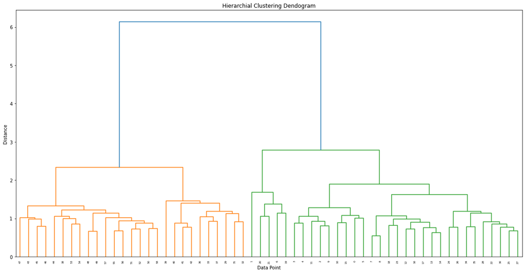

```python
#dendrogram showing hierarchial clustering process
plt.figure(figsize=(20, 10))
plt.title('Hierarchial Clustering Dendogram')
plt.xlabel('Data Point')
plt.ylabel('Distance')
dendrogram(z)
```

```python
# document catrgories
from scipy.cluster.hierarchy import fcluster
```

```python
max_dist= 2.0

cluster_labes= fcluster(z, max_dist, criterion= 'distance')
cluster_labes= pd.DataFrame(cluster_labes, columns= ['cluster_label'])
cluster_df= pd.concat([speech_df, cluster_labes], axis= 1)
```

```python
#sort by cluster
cluster_df.sort_values(by=['cluster_label'])
```

|  | year | president | speeches | speeches_norm | party | cluster_label |
| --- | --- | --- | --- | --- | --- | --- |
| 58 | 2021 | Biden | Chief Justice Roberts, Vice President Harris, ... | chief justice roberts vice president harris sp... | democrat | 1 |
| 38 | 1941 | Roosevel | On each national day of inauguration since 178... | national day inauguration since 1789 people re... | democrat | 1 |
| 43 | 1961 | Kennedy | Vice President Johnson, Mr. Speaker, Mr. Chief... | vice president johnson mr speaker mr chief jus... | democrat | 1 |
| 44 | 1965 | Johnson | My fellow countrymen, on this occasion, the oa... | fellow countryman occasion oath take god not m... | democrat | 1 |
| 46 | 1973 | Nixon | Mr. Vice President, Mr. Speaker, Mr. Chief Jus... | mr vice president mr speaker mr chief justice ... | republican | 1 |
| 47 | 1977 | Carter | For myself and for our Nation, I want to thank... | nation want thank predecessor heal land outwar... | democrat | 1 |
| 48 | 1981 | Reagan | Senator Hatfield, Mr. Chief Justice, Mr. Presi... | senator hatfield mr chief justice mr president... | republican | 1 |
| 49 | 1985 | Reagan | Senator Mathias, Chief Justice Burger, Vice Pr... | senator mathias chief justice burger vice pres... | republican | 1 |
| 45 | 1969 | Nixon | Senator Dirksen, Mr. Chief Justice, Mr. Vice P... | senator dirksen mr chief justice mr vice presi... | republican | 1 |
| 51 | 1993 | Clinton | My fellow citizens, today we celebrate the mys... | fellow citizen today celebrate mystery america... | democrat | 1 |
| 56 | 2013 | Obama | Thank you. Thank you so much.\n\nVice Presiden... | thank thank much vice president biden mr chief... | democrat | 1 |
| 50 | 1989 | Bush | Mr. Chief Justice, Mr. President, Vice Preside... | mr chief justice mr president vice president q... | republican | 1 |
| 55 | 2009 | Obama | My fellow citizens:\n\nI stand here today humb... | fellow citizen stand today humble task gratefu... | democrat | 1 |
| 57 | 2017 | Trump | Chief Justice Roberts, President Carter, Presi... | chief justice roberts president carter preside... | republican | 1 |
| 53 | 2001 | Bush | President Clinton, distinguished guests and my... | president clinton distinguished guest fellow c... | republican | 1 |
| 52 | 1997 | Clinton | My fellow citizens: At this last presidential ... | fellow citizen last presidential inauguration ... | democrat | 1 |
| 54 | 2005 | Bush | Vice President Cheney, Mr. Chief Justice, Pres... | vice president cheney mr chief justice preside... | republican | 1 |
| 31 | 1913 | Wilson | There has been a change of government. It bega... | change government begin two year ago house rep... | democrat | 2 |
| 42 | 1957 | Eisenhower | The Price of Peace\nMr. Chairman, Mr. Vice Pre... | price peace mr chairman mr vice president mr c... | republican | 2 |
| 41 | 1953 | Eisenhower | My friends, before I begin the expression of t... | friend begin expression thought deem appropria... | republican | 2 |
| 39 | 1945 | Roosevel | Chief Justice, Mr. Vice President, my friends,... | chief justice mr vice president friend underst... | democrat | 2 |
| 37 | 1937 | Roosevel | When four years ago we met to inaugurate a Pre... | four year ago meet inaugurate president republ... | democrat | 2 |
| 36 | 1933 | Roosevel | I am certain that my fellow Americans expect t... | certain fellow americans expect induction pres... | democrat | 2 |
| 33 | 1921 | Harding | My Countrymen:\n\nWhen one surveys the world a... | countryman one survey world great storm note m... | republican | 2 |
| 32 | 1917 | Wilson | My Fellow citizens: The four years which have ... | fellow citizen four year elapse since last sta... | democrat | 2 |
| 40 | 1949 | Truman | Mr. Vice President, Mr. Chief Justice, and fel... | mr vice president mr chief justice fellow citi... | democrat | 2 |
| 29 | 1905 | Roosevel | My fellow citizens, no people on earth have mo... | fellow citizen no people earth because thankfu... | republican | 2 |
| 1 | 1793 | Washington | Fellow citizens, I am again called upon by the... | fellow citizen call upon voice country execute... | other | 3 |
| 19 | 1865 | Lincoln | Fellow-Countrymen:\n\nAt this second appearing... | fellow countryman second appear take oath pres... | rebublican | 3 |
| 6 | 1813 | Madison | About to add the solemnity of an oath to the o... | add solemnity oath obligation impose second ca... | other | 3 |
| 20 | 1869 | Gran | Citizens of the United States:\n\nYour suffrag... | citizen united states suffrage elect office pr... | republican | 3 |
| 21 | 1873 | Gran | Fellow-Citizens:\n\nUnder Providence I have be... | fellow citizen providence call second time act... | republican | 3 |
| 27 | 1897 | McKinley | Fellow citizens, In obedience to the will of t... | fellow citizen obedience people presence autho... | republican | 4 |
| 11 | 1833 | Jackson | Fellow citizens, the will of the American peop... | fellow citizen american people express unsolic... | democrat | 4 |
| 10 | 1829 | Jackson | Fellow citizens, about to undertake the arduou... | fellow citizen undertake arduous duty appoint ... | democrat | 4 |
| 9 | 1825 | Adams | In compliance with an usage coeval with the ex... | compliance usage coeval existence federal cons... | other | 4 |
| 8 | 1821 | Monroe | Fellow citizens, I shall not attempt to descri... | fellow citizen shall not attempt describe grat... | other | 4 |
| 7 | 1817 | Monroe | I should be destitute of feeling if I was not ... | destitute feeling not deeply affect strong pro... | other | 4 |
| 5 | 1809 | Madison | Unwilling to depart from examples of the most ... | unwilling depart example revered authority ava... | other | 4 |
| 4 | 1805 | Jefferson | Proceeding, fellow citizens, to that qualifica... | proceed fellow citizen qualification constitut... | other | 4 |
| 3 | 1801 | Jefferson | Friends and Fellow Citizens:\n\nCalled upon to... | friend fellow citizen call upon undertake duty... | other | 4 |
| 2 | 1797 | Adams | When it was first perceived, in early times, t... | first perceive early time no middle course ame... | other | 4 |
| 12 | 1837 | VanBuren | Fellow citizens: The practice of all my predec... | fellow citizen practice predecessor impose obl... | democrat | 4 |
| 13 | 1841 | Harrison | Called from a retirement which I had supposed ... | call retirement suppose continue residue life ... | other | 4 |
| 15 | 1849 | Taylor | Elected by the American people to the highest ... | elect american people high office know law app... | other | 4 |
| 26 | 1893 | Cleveland | My Fellow citizens, in obedience of the mandat... | fellow citizen obedience mandate countryman de... | democrat | 4 |
| 16 | 1853 | Pierce | My Countrymen, It a relief to feel that no hea... | countryman relief feel no heart know personal ... | democrat | 4 |
| 17 | 1857 | Buchanan | Fellow citizens, I appear before you this day ... | fellow citizen appear day take solemn oath fai... | democrat | 4 |
| 18 | 1861 | Lincoln | Fellow-Citizens of the United States: In compl... | fellow citizen united states compliance custom... | republican | 4 |
| 35 | 1929 | Hoover | My Countrymen: This occasion is not alone the ... | countryman occasion not alone administration s... | republican | 4 |
| 34 | 1925 | Coolidge | My countrymen,\n\nno one can contemplate curre... | countryman no one contemplate current conditio... | republican | 4 |
| 22 | 1877 | Hayes | Fellow citizens, we have assembled to repeat t... | fellow citizen assemble repeat public ceremoni... | republican | 4 |
| 23 | 1881 | Garfield | Fellow-Citizens:\n\nWe stand to-day upon an em... | fellow citizen stand day upon eminence overloo... | republican | 4 |
| 24 | 1885 | Cleveland | Fellow citizens, in the presence of this vast ... | fellow citizen presence vast assemblage countr... | democrat | 4 |
| 30 | 1909 | Taf | My fellow citizens: Anyone who has taken the o... | fellow citizen anyone take oath take must feel... | republican | 4 |
| 25 | 1889 | Harrison | Fellow-Citizens, there is no constitutional or... | fellow citizen no constitutional legal require... | republican | 4 |
| 28 | 1901 | McKinley | My fellow-citizens, when we assembled here on ... | fellow citizen assemble 4th march 1897 great a... | republican | 4 |
| 14 | 1845 | Polk | Fellow citizens, without solicitation on my pa... | fellow citizen without solicitation part choos... | democrat | 4 |
| 0 | 1789 | Washington | Fellow-Citizens of the Senate and of the House... | fellow citizen senate house representatives am... | other | 4 |

```python
'''
Stack Overflow
https://stackoverflow.com/questions/20995196/pandas-counting-and-summing-specific-conditions
'''

#how many of each party in the 4 clusters
dem_1= cluster_df[(cluster_df.party == "democrat") & (cluster_df.cluster_label == 1)].count()["cluster_label"]
dem_2= cluster_df[(cluster_df.party == "democrat") & (cluster_df.cluster_label == 2)].count()["cluster_label"]
dem_3= cluster_df[(cluster_df.party == "democrat") & (cluster_df.cluster_label == 3)].count()["cluster_label"]
dem_4= cluster_df[(cluster_df.party == "democrat") & (cluster_df.cluster_label == 4)].count()["cluster_label"]

rep_1= cluster_df[(cluster_df.party == "republican") & (cluster_df.cluster_label == 1)].count()["cluster_label"]
rep_2= cluster_df[(cluster_df.party == "republican") & (cluster_df.cluster_label == 2)].count()["cluster_label"]
rep_3= cluster_df[(cluster_df.party == "republican") & (cluster_df.cluster_label == 3)].count()["cluster_label"]
rep_4= cluster_df[(cluster_df.party == "republican") & (cluster_df.cluster_label == 4)].count()["cluster_label"]

oth_1= cluster_df[(cluster_df.party == "other") & (cluster_df.cluster_label == 1)].count()["cluster_label"]
oth_2= cluster_df[(cluster_df.party == "other") & (cluster_df.cluster_label == 2)].count()["cluster_label"]
oth_3= cluster_df[(cluster_df.party == "other") & (cluster_df.cluster_label == 3)].count()["cluster_label"]
oth_4= cluster_df[(cluster_df.party == "other") & (cluster_df.cluster_label == 4)].count()["cluster_label"]

party_data= [['democrat', dem_1, dem_2, dem_3, dem_4], ['republican', rep_1, rep_2, rep_3, rep_4], ['other', oth_1, oth_2, oth_3, oth_4]]
party_df= pd.DataFrame(party_data, columns= ['party', 'cluster 1', 'cluster 2', 'cluster 3', 'cluster 4'])
party_df.loc['total',:]= party_df.sum(axis=0)
party_df.loc[:, 'total']= party_df.sum(axis=1)
party_df
```

|  | party | cluster 1 | cluster 2 | cluster 3 | cluster 4 | total |
| --- | --- | --- | --- | --- | --- | --- |
| 0 | democrat | 9.0 | 6.0 | 0.0 | 8.0 | 23.0 |
| 1 | republican | 8.0 | 4.0 | 2.0 | 9.0 | 23.0 |
| 2 | other | 0.0 | 0.0 | 2.0 | 10.0 | 12.0 |
| total | democratrepublicanother | 17.0 | 10.0 | 4.0 | 27.0 | 58.0 |

As you can see with the result of the clustering the results are not ideal. There are 4 clusters generated, and there is not a single cluster that appears to define one of the parties over the other. The appear to be dispersed relatively evenly across the parties, except for the Other parties which fall predominately in cluser 4.

### Top Words for Each Party

Here I would like to look at the top words used in the speeches for each of the parties. When normalizing the speeches I left the words 'no' and 'not' in the context to denote sentiment better and look to see if those words show up more in one party than another and they tend to denote a negative tone.

I will create a word cloud for each party to better visualize the differences in the top words.

```python
#tokenize into words
wt= nltk.word_tokenize

def word_tokens_15(array):
    string= ' '.join(array)
    words= wt(string)
    counter= Counter(words)
    most_common= counter.most_common(15)
    most_common= dict(most_common)
    return most_common

def word_tokens_30(array):
    string= ' '.join(array)
    words= wt(string)
    counter= Counter(words)
    most_common= counter.most_common(30)
    most_common= dict(most_common)
    return most_common

#other parties
other_most_common= word_tokens_15(other_norm_array)
other_most_common
```

```
{'not': 166,
 'government': 157,
 'power': 122,
 'great': 108,
 'may': 107,
 'citizen': 106,
 'people': 105,
 'country': 96,
 'nation': 90,
 'no': 83,
 'states': 80,
 'public': 74,
 'every': 73,
 'constitution': 73,
 'duty': 68}
```

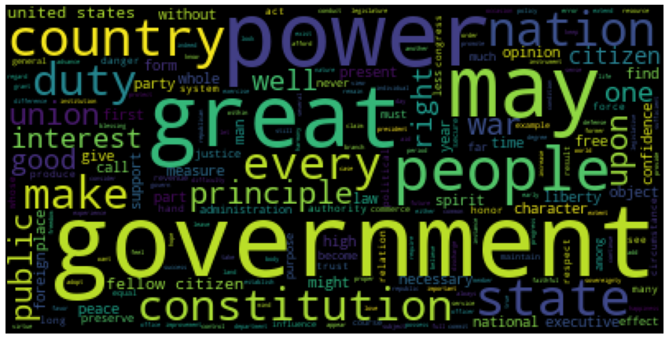

```python
'''
Medium
https://medium.com/@siglimumuni/natural-language-processing-in-python-exploring-word-frequencies-with-nltk-918f33c1e4c3

Stack Overflow
https://stackoverflow.com/questions/69447823/how-to-convert-array-to-string-in-python
'''
def word_cloud(string):
    wordcloud= WordCloud(background_color= 'black').generate(string)

    plt.figure(figsize= (15, 8))
    plot= plt.imshow(wordcloud)

    plt.axis('off')

    return plot

#create string of words
other_string= ' '.join(str(x) for x in other_norm_array)

#other word cloud
word_cloud(other_string)
```

```python
#democratic party
democrat_most_common= word_tokens_15(democrat_norm_array)
democrat_most_common
```

```
{'not': 363,
 'people': 239,
 'government': 210,
 'nation': 204,
 'must': 148,
 'no': 135,
 'world': 133,
 'power': 127,
 'great': 127,
 'shall': 122,
 'every': 120,
 'new': 120,
 'upon': 117,
 'time': 106,
 'may': 103}
```

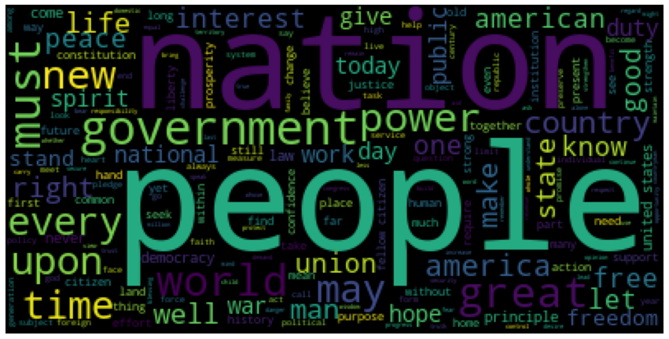

```python
#create string of words
democrat_string= ' '.join(str(x) for x in democrat_norm_array)

#democrat word cloud
word_cloud(democrat_string)
```

```python
#republican party
republican_most_common= word_tokens_15(republican_norm_array)
republican_most_common
```

```
{'not': 522,
 'people': 289,
 'government': 282,
 'no': 250,
 'nation': 220,
 'great': 205,
 'make': 198,
 'must': 198,
 'world': 197,
 'upon': 191,
 'law': 183,
 'country': 161,
 'peace': 138,
 'one': 132,
 'america': 132}
```

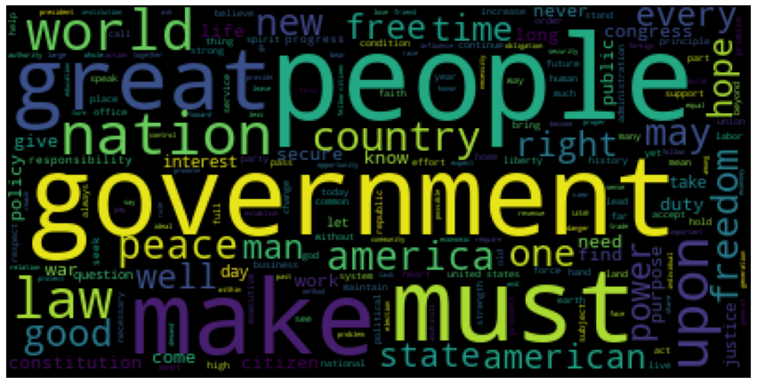

```python
#create string of words
republican_string= ' '.join(str(x) for x in republican_norm_array)

#republican word cloud
word_cloud(republican_string)
```

```python
#create list of total top words
total_most_common= word_tokens_30(speech_norm_array)
total_most_common
```

```
{'not': 1055,
 'government': 650,
 'people': 633,
 'nation': 518,
 'no': 470,
 'great': 441,
 'must': 374,
 'upon': 371,
 'country': 359,
 'make': 354,
 'world': 348,
 'may': 343,
 'power': 341,
 'shall': 316,
 'citizen': 304,
 'every': 300,
 'states': 284,
 'one': 282,
 'time': 274,
 'law': 266,
 'peace': 259,
 'right': 256,
 'new': 255,
 'good': 253,
 'man': 251,
 'well': 242,
 'america': 232,
 'public': 227,
 'would': 218,
 'constitution': 213}
```

Interestingly enough the top word for each party was 'not.' What I did not see was a wide variance in the words used and their rankings in the scores of highest words. Though the word clouds show some variance, they are quite similar to eachother. This explains the evenly distributed clusers in the prior section of the projet.

### Sentiment Analysis - Democrats

The final section of the project is to review the sentiment of each parties speeches. This was my culminating goal and the area I thought the speeches would differ most. I will look at each of the parties respectively and compare their sentiments to eachother at the end.

```python
#genism models
from afinn import Afinn
```

```python
'''
Text Analytics with Python
Dipanjan Sarkar
Used throughout assignment

Sentiment Analysis Using Afinn
Geeks for Geeks
https://www.geeksforgeeks.org/python-sentiment-analysis-using-affin/
'''
```

```
'\nText Analytics with Python\nDipanjan Sarkar\nUsed throughout assignment\n\nSentiment Analysis Using Afinn\nGeeks for Geeks\nhttps://www.geeksforgeeks.org/python-sentiment-analysis-using-affin/\n'
```

```python
#instantiate Afinn
afn= Afinn()
```

```python
#sentiment scores
scores= [afn.score(article) for article in democrat_norm_array]
```

```python
#set score values
sentiment = ['positive' if score > 150
                          else 'negative' if score < 100
                              else 'neutral'
                                  for score in scores]
```

```python
#create dataframe
democrat['scores']= scores
democrat['sentiments']= sentiment
```

```python
democrat
```

|  | year | president | speeches | speeches_norm | party | scores | sentiments |
| --- | --- | --- | --- | --- | --- | --- | --- |
| 10 | 1829 | Jackson | Fellow citizens, about to undertake the arduou... | fellow citizen undertake arduous duty appoint ... | democrat | 113.0 | neutral |
| 11 | 1833 | Jackson | Fellow citizens, the will of the American peop... | fellow citizen american people express unsolic... | democrat | 87.0 | negative |
| 12 | 1837 | VanBuren | Fellow citizens: The practice of all my predec... | fellow citizen practice predecessor impose obl... | democrat | 202.0 | positive |
| 14 | 1845 | Polk | Fellow citizens, without solicitation on my pa... | fellow citizen without solicitation part choos... | democrat | 296.0 | positive |
| 16 | 1853 | Pierce | My Countrymen, It a relief to feel that no hea... | countryman relief feel no heart know personal ... | democrat | 266.0 | positive |
| 17 | 1857 | Buchanan | Fellow citizens, I appear before you this day ... | fellow citizen appear day take solemn oath fai... | democrat | 218.0 | positive |
| 24 | 1885 | Cleveland | Fellow citizens, in the presence of this vast ... | fellow citizen presence vast assemblage countr... | democrat | 170.0 | positive |
| 26 | 1893 | Cleveland | My Fellow citizens, in obedience of the mandat... | fellow citizen obedience mandate countryman de... | democrat | 122.0 | neutral |
| 31 | 1913 | Wilson | There has been a change of government. It bega... | change government begin two year ago house rep... | democrat | 74.0 | negative |
| 32 | 1917 | Wilson | My Fellow citizens: The four years which have ... | fellow citizen four year elapse since last sta... | democrat | 116.0 | neutral |
| 36 | 1933 | Roosevel | I am certain that my fellow Americans expect t... | certain fellow americans expect induction pres... | democrat | 95.0 | negative |
| 37 | 1937 | Roosevel | When four years ago we met to inaugurate a Pre... | four year ago meet inaugurate president republ... | democrat | 109.0 | neutral |
| 38 | 1941 | Roosevel | On each national day of inauguration since 178... | national day inauguration since 1789 people re... | democrat | 40.0 | negative |
| 39 | 1945 | Roosevel | Chief Justice, Mr. Vice President, my friends,... | chief justice mr vice president friend underst... | democrat | 61.0 | negative |
| 40 | 1949 | Truman | Mr. Vice President, Mr. Chief Justice, and fel... | mr vice president mr chief justice fellow citi... | democrat | 255.0 | positive |
| 43 | 1961 | Kennedy | Vice President Johnson, Mr. Speaker, Mr. Chief... | vice president johnson mr speaker mr chief jus... | democrat | 47.0 | negative |
| 44 | 1965 | Johnson | My fellow countrymen, on this occasion, the oa... | fellow countryman occasion oath take god not m... | democrat | 64.0 | negative |
| 47 | 1977 | Carter | For myself and for our Nation, I want to thank... | nation want thank predecessor heal land outwar... | democrat | 125.0 | neutral |
| 51 | 1993 | Clinton | My fellow citizens, today we celebrate the mys... | fellow citizen today celebrate mystery america... | democrat | 63.0 | negative |
| 52 | 1997 | Clinton | My fellow citizens: At this last presidential ... | fellow citizen last presidential inauguration ... | democrat | 168.0 | positive |
| 55 | 2009 | Obama | My fellow citizens:\n\nI stand here today humb... | fellow citizen stand today humble task gratefu... | democrat | 96.0 | negative |
| 56 | 2013 | Obama | Thank you. Thank you so much.\n\nVice Presiden... | thank thank much vice president biden mr chief... | democrat | 105.0 | neutral |
| 58 | 2021 | Biden | Chief Justice Roberts, Vice President Harris, ... | chief justice roberts vice president harris sp... | democrat | 86.0 | negative |

### Sentiment Analysis - Republicans

```python
scores= [afn.score(article) for article in republican_norm_array]
```

```python
sentiment = ['positive' if score > 150
                          else 'negative' if score < 100
                              else 'neutral'
                                  for score in scores]
```

```python
republican['scores']= scores
republican['sentiments']= sentiment
```

```python
republican
```

|  | year | president | speeches | speeches_norm | party | scores | sentiments |
| --- | --- | --- | --- | --- | --- | --- | --- |
| 18 | 1861 | Lincoln | Fellow-Citizens of the United States: In compl... | fellow citizen united states compliance custom... | republican | 0.0 | negative |
| 20 | 1869 | Gran | Citizens of the United States:\n\nYour suffrag... | citizen united states suffrage elect office pr... | republican | 103.0 | neutral |
| 21 | 1873 | Gran | Fellow-Citizens:\n\nUnder Providence I have be... | fellow citizen providence call second time act... | republican | 69.0 | negative |
| 22 | 1877 | Hayes | Fellow citizens, we have assembled to repeat t... | fellow citizen assemble repeat public ceremoni... | republican | 234.0 | positive |
| 23 | 1881 | Garfield | Fellow-Citizens:\n\nWe stand to-day upon an em... | fellow citizen stand day upon eminence overloo... | republican | 132.0 | neutral |
| 25 | 1889 | Harrison | Fellow-Citizens, there is no constitutional or... | fellow citizen no constitutional legal require... | republican | 241.0 | positive |
| 27 | 1897 | McKinley | Fellow citizens, In obedience to the will of t... | fellow citizen obedience people presence autho... | republican | 305.0 | positive |
| 28 | 1901 | McKinley | My fellow-citizens, when we assembled here on ... | fellow citizen assemble 4th march 1897 great a... | republican | 123.0 | neutral |
| 29 | 1905 | Roosevel | My fellow citizens, no people on earth have mo... | fellow citizen no people earth because thankfu... | republican | 68.0 | negative |
| 30 | 1909 | Taf | My fellow citizens: Anyone who has taken the o... | fellow citizen anyone take oath take must feel... | republican | 305.0 | positive |
| 33 | 1921 | Harding | My Countrymen:\n\nWhen one surveys the world a... | countryman one survey world great storm note m... | republican | 156.0 | positive |
| 34 | 1925 | Coolidge | My countrymen,\n\nno one can contemplate curre... | countryman no one contemplate current conditio... | republican | 331.0 | positive |
| 35 | 1929 | Hoover | My Countrymen: This occasion is not alone the ... | countryman occasion not alone administration s... | republican | 226.0 | positive |
| 41 | 1953 | Eisenhower | My friends, before I begin the expression of t... | friend begin expression thought deem appropria... | republican | 191.0 | positive |
| 42 | 1957 | Eisenhower | The Price of Peace\nMr. Chairman, Mr. Vice Pre... | price peace mr chairman mr vice president mr c... | republican | 173.0 | positive |
| 45 | 1969 | Nixon | Senator Dirksen, Mr. Chief Justice, Mr. Vice P... | senator dirksen mr chief justice mr vice presi... | republican | 169.0 | positive |
| 46 | 1973 | Nixon | Mr. Vice President, Mr. Speaker, Mr. Chief Jus... | mr vice president mr speaker mr chief justice ... | republican | 199.0 | positive |
| 48 | 1981 | Reagan | Senator Hatfield, Mr. Chief Justice, Mr. Presi... | senator hatfield mr chief justice mr president... | republican | 156.0 | positive |
| 49 | 1985 | Reagan | Senator Mathias, Chief Justice Burger, Vice Pr... | senator mathias chief justice burger vice pres... | republican | 191.0 | positive |
| 50 | 1989 | Bush | Mr. Chief Justice, Mr. President, Vice Preside... | mr chief justice mr president vice president q... | republican | 263.0 | positive |
| 53 | 2001 | Bush | President Clinton, distinguished guests and my... | president clinton distinguished guest fellow c... | republican | 125.0 | neutral |
| 54 | 2005 | Bush | Vice President Cheney, Mr. Chief Justice, Pres... | vice president cheney mr chief justice preside... | republican | 172.0 | positive |
| 57 | 2017 | Trump | Chief Justice Roberts, President Carter, Presi... | chief justice roberts president carter preside... | republican | 148.0 | neutral |

### Sentiment Analysis - Other

```python
scores= [afn.score(article) for article in other_norm_array]
```

```python
sentiment = ['positive' if score > 150
                          else 'negative' if score < 100
                              else 'neutral'
                                  for score in scores]
```

```python
other['scores']= scores
other['sentiments']= sentiment
```

```python
other
```

|  | year | president | speeches | speeches_norm | party | scores | sentiments |
| --- | --- | --- | --- | --- | --- | --- | --- |
| 0 | 1789 | Washington | Fellow-Citizens of the Senate and of the House... | fellow citizen senate house representatives am... | other | 128.0 | neutral |
| 1 | 1793 | Washington | Fellow citizens, I am again called upon by the... | fellow citizen call upon voice country execute... | other | 4.0 | negative |
| 2 | 1797 | Adams | When it was first perceived, in early times, t... | first perceive early time no middle course ame... | other | 195.0 | positive |
| 3 | 1801 | Jefferson | Friends and Fellow Citizens:\n\nCalled upon to... | friend fellow citizen call upon undertake duty... | other | 150.0 | neutral |
| 4 | 1805 | Jefferson | Proceeding, fellow citizens, to that qualifica... | proceed fellow citizen qualification constitut... | other | 95.0 | negative |
| 5 | 1809 | Madison | Unwilling to depart from examples of the most ... | unwilling depart example revered authority ava... | other | 120.0 | neutral |
| 6 | 1813 | Madison | About to add the solemnity of an oath to the o... | add solemnity oath obligation impose second ca... | other | 16.0 | negative |
| 7 | 1817 | Monroe | I should be destitute of feeling if I was not ... | destitute feeling not deeply affect strong pro... | other | 351.0 | positive |
| 8 | 1821 | Monroe | Fellow citizens, I shall not attempt to descri... | fellow citizen shall not attempt describe grat... | other | 282.0 | positive |
| 9 | 1825 | Adams | In compliance with an usage coeval with the ex... | compliance usage coeval existence federal cons... | other | 207.0 | positive |
| 13 | 1841 | Harrison | Called from a retirement which I had supposed ... | call retirement suppose continue residue life ... | other | 313.0 | positive |
| 15 | 1849 | Taylor | Elected by the American people to the highest ... | elect american people high office know law app... | other | 118.0 | neutral |

### Count All Sentiments

```python
democrat_positive= democrat.loc[democrat.sentiments == 'positive', 'sentiments'].count()
democrat_neutral= democrat.loc[democrat.sentiments == 'neutral', 'sentiments'].count()
democrat_negative= democrat.loc[democrat.sentiments == 'negative', 'sentiments'].count()

republican_positive= republican.loc[republican.sentiments == 'positive', 'sentiments'].count()
republican_neutral= republican.loc[republican.sentiments == 'neutral', 'sentiments'].count()
republican_negative= republican.loc[republican.sentiments == 'negative', 'sentiments'].count

other_positive= other.loc[other.sentiments == 'positive', 'sentiments'].count()
other_neutral= other.loc[other.sentiments == 'neutral', 'sentiments'].count()
other_negative= other.loc[other.sentiments == 'negative', 'sentiments'].count()
```

```python
other_total = other['sentiments'].count()
democrat_total= democrat['sentiments'].count()
republican_total= republican['sentiments'].count()
```

```python
dem_per_pos= democrat_positive / democrat_total * 100
dem_per_neu= democrat_neutral / democrat_total * 100
dem_per_neg= democrat_negative / democrat_total * 100
```

```python
rep_per_pos= republican_positive / republican_total * 100
rep_per_neu= republican_neutral / republican_total * 100
#rep_per_neg= republican_negative / republican_total * 100
rep_per_neg= 100 - rep_per_neu - rep_per_pos
```

```python
oth_per_pos= other_positive / other_total * 100
oth_per_neu= other_neutral / other_total * 100
oth_per_neg= other_negative / other_total * 100
```

```python
print(f'Percent Positive Democratic Speeches is: {dem_per_pos}')
print(f'Percent Positive Republican Speeches is: {rep_per_pos}')
print(f'Percent Positive Other Speeches is: {oth_per_pos}')
```

```
Percent Positive Democratic Speeches is: 30.434782608695656
Percent Positive Republican Speeches is: 65.21739130434783
Percent Positive Other Speeches is: 41.66666666666667
```

```python
print(f'Percent Neutral Democratic Speeches is: {dem_per_neu}')
print(f'Percent Neutral Republican Speeches is: {rep_per_neu}')
print(f'Percent Neutral Other Speeches is: {oth_per_neu}')
```

```
Percent Neutral Democratic Speeches is: 26.08695652173913
Percent Neutral Republican Speeches is: 21.73913043478261
Percent Neutral Other Speeches is: 33.33333333333333
```

```python
print(f'Percent Negative Democratic Speeches is: {dem_per_neg}')
print(f'Percent Negative Republican Speeches is: {rep_per_neg}')
print(f'Percent Negative Other Speeches is: {oth_per_neg}')
```

```
Percent Negative Democratic Speeches is: 43.47826086956522
Percent Negative Republican Speeches is: 13.043478260869563
Percent Negative Other Speeches is: 25.0
```

In conclusion, though there are not much difference in the words used for the different parties inagural speeches, there is a distinct difference in the context in which those same words are used.

```python
import os
```

```python
os.system('jupyter nbconvert --to html Term_Project.ipynb')
```

```
0
```